# Membuat Grafik

Muhammad Aswan Syahputra

Paket ggplot2 adalah implementasi dari konsep *Grammar of graphic* untuk bahasa pemrograman R. Anda dapat membaca artikel mengenai konsep implementasi ggplot2 tersebut melalui pranala [ini](http://vita.had.co.nz/papers/layered-grammar.pdf). Dengan memahami konsep dari *grammar of graphic*, Anda dapat membuat berbagai jenis plot dengan ringkas dan mudah. Mari kita perhatikan kembali struktur umum penulisan kode R untuk membuat grafik menggunakan paket ggplot2:

```
ggplot(data = <DATA>) +
  <GEOM_FUNCTION>(mapping = aes(<MAPPINGS>))
```

Anda dapat menarik kesimpulan berdasarkan struktur penulisan kode R di atas bahwa setidaknya terdapat tiga komponen utama untuk membuat grafik, yaitu:

- *Data*
- *Aesthetic mapping*
- *Geometric object*

Sekarang Anda dipersilakan untuk mengaktifkan paket tidyverse untuk mengimpor, mengolah, dan visualisasi data dengan cara mengisi bagian ___ dengan jawaban yang tepat! (Catatan: paket tidyverse berfungsi untuk mengaktifkan paket readr, tibble, tidyr, dplyr, ggplot2, dan purrr)

```r
library(tidyverse)
```

Dalam contoh ini Anda akan menggunakan data *Indonesia Database for Policy and Economic Research* dari [The World Bank](https://datacatalog.worldbank.org/dataset/indonesia-database-policy-and-economic-research). Data tersebut tersedia dalam berkas indodapoer.csv di dalam direktori data-raw.

```r
indodapoer <- read_csv("../data-raw/indodapoer.csv")
dim(indodapoer)
```

```
## [1] 22468   222
```

```r
colnames(indodapoer)
```

```
##   [1] "province_or_district"
##   [2] "year"
##   [3] "agriculture_function_expenditure_in_idr"
##   [4] "average_national_exam_score_junior_secondary_level_out_of_100_available_only_in_district_level_for_2009"
##   [5] "average_national_exam_score_primary_level_out_of_100_available_only_in_district_level_for_2009"
##   [6] "average_national_exam_score_senior_secondary_level_out_of_100_available_only_in_district_level_for_2009"
##   [7] "birth_attended_by_skilled_health_worker_in_percent_of_total_birth"
##   [8] "bpk_audit_report_on_sub_national_budget"
##   [9] "capital_expenditure_in_idr"
##  [10] "consumer_price_index_in_42_cities_base_1996"
##  [11] "consumer_price_index_in_45_cities_base_2002"
##  [12] "consumer_price_index_in_66_cities_base_2007"
##  [13] "economy_function_expenditure_in_idr"
##  [14] "education_function_expenditure_in_idr"
##  [15] "environment_function_expenditure_in_idr"
```

[output cut: 207 more lines]

Dataset indodapoer tersebut memiliki sangat banyak informasi seperti terlihat setelah Anda menjalankan fungsi `dim()` dan `colnames()` di atas. Kita akan berfokus pada informasi mengenai *Gross Domestic Product* (GDP) per provinsi dan mengekstraknya menjadi dataset baru dengan nama `gdp_id` dengan menggunakan baris kode pada *chunk* berikut:

```r
gdp_id <-
  indodapoer %>%
  filter(str_detect(province_or_district, "Prop")) %>%
    select(province = province_or_district,
           year,
           population = total_population_in_number_of_people,
           matches("gdp_on.*constant"),
           matches("total_gdp.*constant")) %>%
                rename_all(~str_remove_all(., "(?:gdp_on_|_sector_in_idr_million_constant_price|_in_idr_million_constant_price)")) %>%
                mutate(province = str_remove(province, ", Prop."))
glimpse(gdp_id)
```

```
## Observations: 1,394
## Variables: 14
## $ province                             <chr> "Bali", "Bali", "Bali", "...
## $ year                                 <dbl> 1976, 1977, 1978, 1979, 1...
## $ population                           <dbl> NA, NA, NA, NA, NA, NA, N...
## $ agriculture                          <dbl> 1220349, 1472457, 1401453...
## $ construction                         <dbl> 233895.9, 288946.0, 28561...
## $ financial_service                    <dbl> 139543.0, 144087.8, 15538...
## $ manufacturing                        <dbl> 108989.4, 126902.2, 16164...
## $ mining_and_quarrying                 <dbl> 44651.11, 52782.11, 62116...
## $ other_service                        <dbl> 484730.6, 508151.6, 52471...
## $ trade_hotel_and_restaurant           <dbl> 398117.3, 499387.9, 60614...
## $ transportation_and_telecommunication <dbl> 205046.5, 234600.9, 26171...
## $ utilities                            <dbl> 3308.478, 4619.913, 4967....
## $ total_gdp_excluding_oil_and_gas      <dbl> NA, NA, NA, NA, NA, NA, N...
## $ total_gdp_including_oil_and_gas      <dbl> 2838631, 3331936, 3463758...
```

## Scatterplot

Selanjutnya kita akan membuat grafik untuk mengetahui pertumbuhan GDP per tahun.

Sebuah grafik yang dibuat menggunakan paket ggplot2 terdiri atas *layers* dari elemen-elemen grafik tersebut.

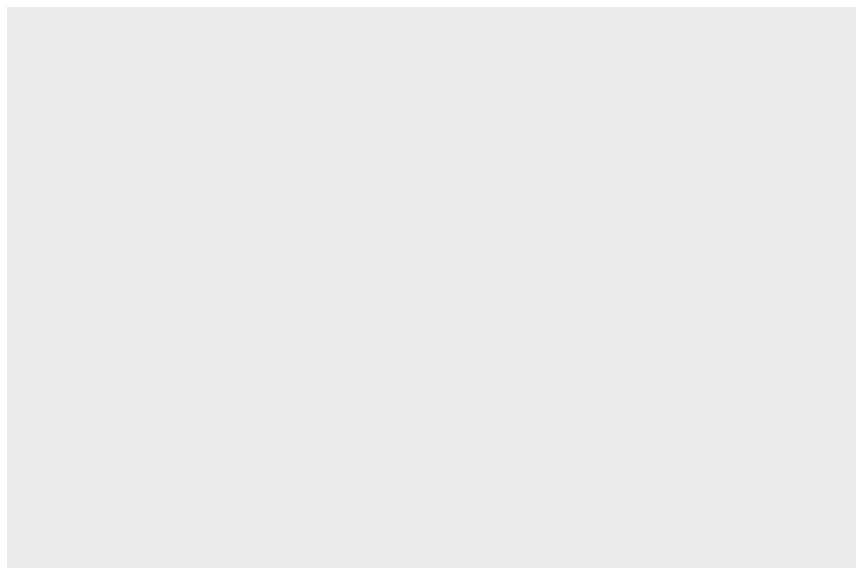

```r
ggplot(gdp_id)
```

Data yang digunakan untuk membuat grafik adalah elemen pertama. Selanjutnya, kita perlu mendefinisikan dimensi mana dari data yang ingin digambarkan dalam grafik. Pendefinisian ini dilakukan dalam komponen *aesthetic mapping* (`aes()`). Kita ingin menginvestigasi pertumbuhan GDP total dari tahun ke tahun. Untuk itu, kita mendefinisikan `year` di sumbu x dan `total_gdp_including_oil_and_gas` di sumbu y. Ubahlah "___" di bawah dengan ekspresi yang sesuai.

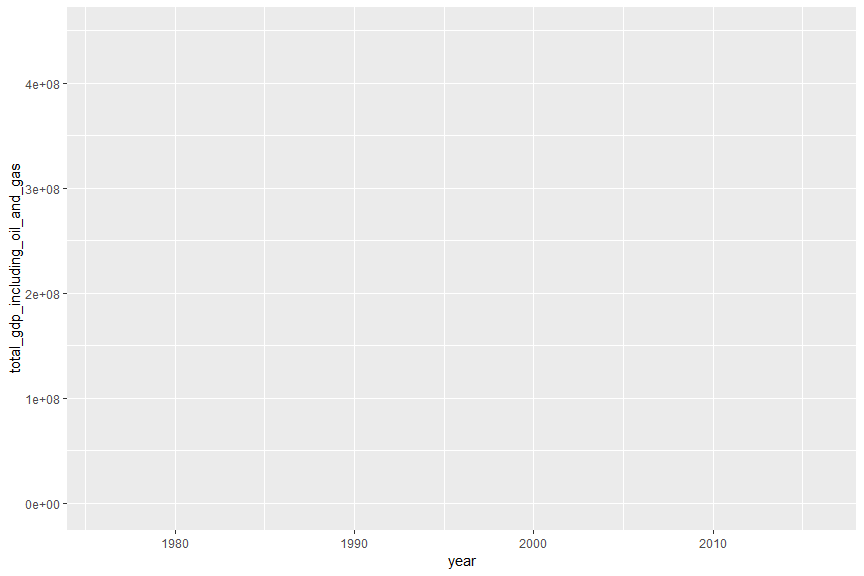

```r
ggplot(gdp_id, aes(x = year, y = total_gdp_including_oil_and_gas))
```

Pendefinisian sumbu x dan y telah menghasilkan layer baru dalam grafik. Namun, kita masih perlu mendefinisikan bentuk dari grafik tersebut melalui komponen *geometric object* (`geom_*()`) sebelum grafik tersebut dapat dibaca. Pertama-tama, kita membuat *scatter plot* di atas *layers* yang telah dibuat sebelumnya.

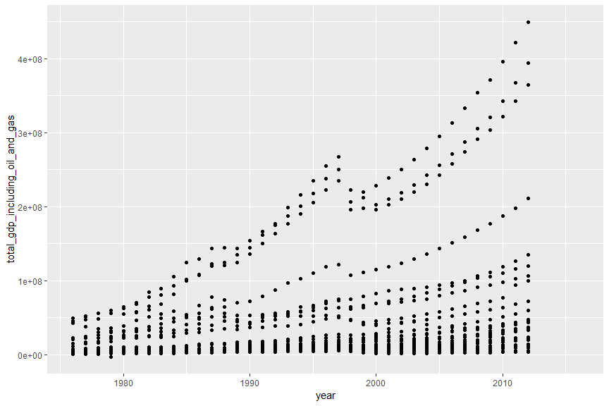

```r
ggplot(gdp_id, aes(x = year, y = total_gdp_including_oil_and_gas)) +
  geom_point()
```

Selain cara penulisan di atas, kita juga dapat membuat grafik yang sama dengan menggunakan operator *pipe* (`%>%`).

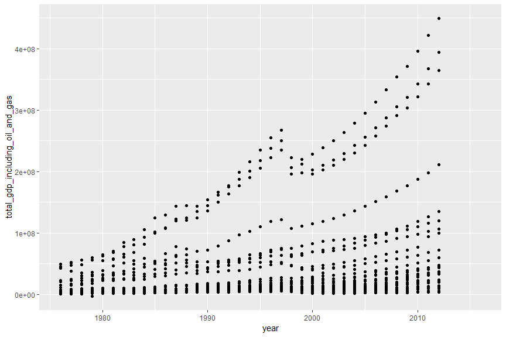

```r
gdp_id %>%
  ggplot(aes(x = year, y = total_gdp_including_oil_and_gas)) +
  geom_point()
```

Penulisan fungsi `ggplot()` di dalam *pipe* bermanfaat ketika kita perlu melakukan pemrosesan awal dari data sebelum dibuatkan grafiknya. Dalam contoh berikut kita hanya ingin menginvestigasi provinsi-provinsi di Pulau Jawa saja sehingga kita menggunakan fungsi `filter()`. Cobalah membuat *scatter plot* untuk melihat hubungan antara `trade_hotel_and_restaurant` pada sumbu x dengan `manufacturing` pada sumbu y. Tambahkan *aesthetic* berupa warna untuk membedakan provinsi-provinsi yang ada.

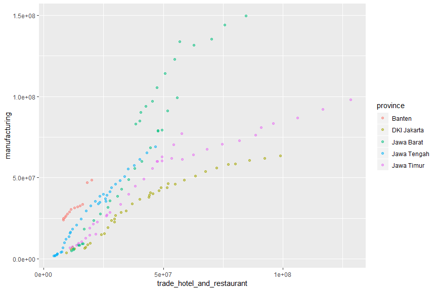

```r
gdp_id %>%
  filter(province %in% c("Banten", "DKI Jakarta", "Jawa Barat", "Jawa Tengah", "Di Yogyakarta", "Jawa Timur")) %>% # ekstrak provinsi di Pulau Jawa
  ggplot(aes(x = trade_hotel_and_restaurant, y = manufacturing, colour = province)) +
  geom_point(alpha = 0.5) +
  scale_size_area()
```

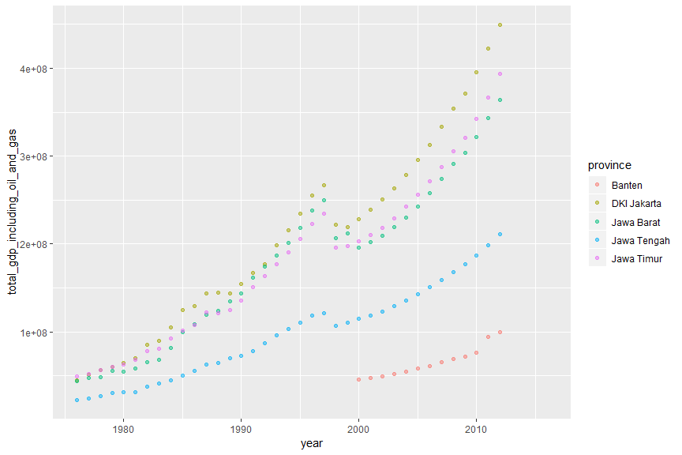

```r
#test data GDP per TAHUN
gdp_id %>%
  filter(province %in% c("Banten", "DKI Jakarta", "Jawa Barat", "Jawa Tengah", "Di Yogyakarta", "Jawa Timur")) %>% # ekstrak provinsi di Pulau Jawa
  ggplot(aes(x = year, y = total_gdp_including_oil_and_gas, colour = province)) +
  geom_point(alpha = 0.5) +
  scale_size_area()
```

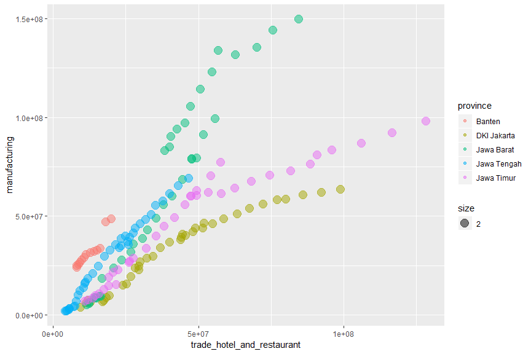

```r
gdp_id %>%
  filter(province %in% c("Banten", "DKI Jakarta", "Jawa Barat", "Jawa Tengah", "Di Yogyakarta", "Jawa Timur")) %>% # ekstrak provinsi di Pulau Jawa
  ggplot(aes(x = trade_hotel_and_restaurant, y = manufacturing, colour = province, size = 2)) +
  geom_point(alpha = 0.5)
```

## Line Graph

Selanjutnya, kita akan mencoba bentuk grafik selanjutnya yaitu grafik garis atau *line graph* dengan fungsi `geom_line()`.

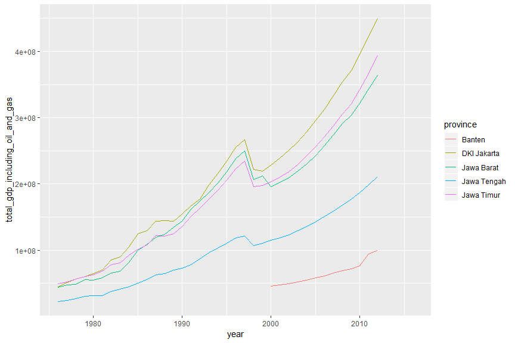

```r
gdp_id %>%
  filter(province %in% c("Banten", "DKI Jakarta", "Jawa Barat", "Jawa Tengah", "Di Yogyakarta", "Jawa Timur")) %>%
  ggplot(aes(x = year, y = total_gdp_including_oil_and_gas, colour = province)) +
  geom_line()
```

Kita juga dapat mengkombinasikan grafik garis dengan titik.

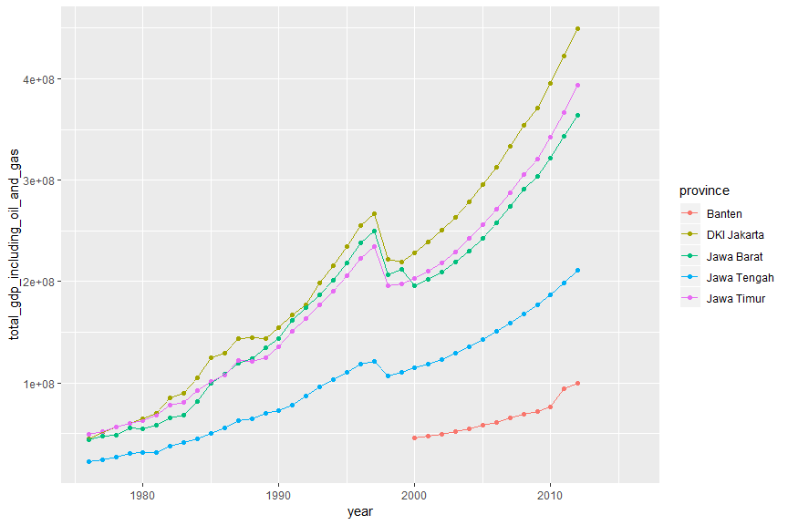

```r
gdp_id %>%
  filter(province %in% c("Banten", "DKI Jakarta", "Jawa Barat", "Jawa Tengah", "Di Yogyakarta", "Jawa Timur")) %>%
  ggplot(aes(x = year, y = total_gdp_including_oil_and_gas, colour = province)) +
  geom_point() +
  geom_line()
```

## Area graph

Jika *line graph* dapat menunjukkan evolusi suatu variabel dari daerah-daerah tertentu terhadap waktu, *area graph* dapat digunakan jika kita juga tertarik melihat kontribusi daerah-daerah tersebut terhadap keseluruhan dalam evolusinya. Cobalah membuat *area graph* populasi terhadap waktu dari provinsi-provinsi yang ada di Kalimantan.

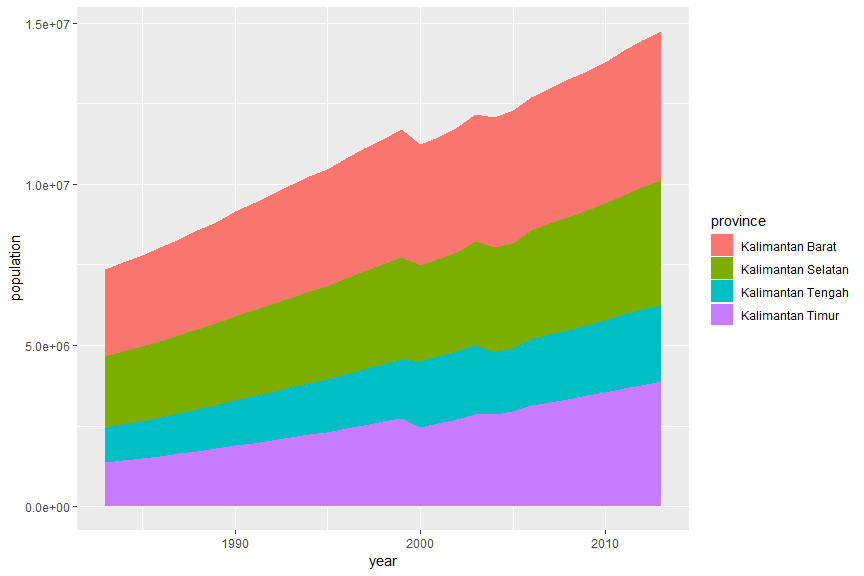

```r
gdp_id %>%
  filter(str_detect(province, "Kalimantan")) %>%
  ggplot(aes(x = year, y = population, fill = province)) +
  geom_area()
```

Jika kita lebih tertarik terhadap kontribusi relatif dibandingkan dengan nilai absolut, kita dapat menambahkan argumen `position = "fill"` pada fungsi `geom_area()`. Ini akan menormalisasi nilai dari variabel terhadap jumlah keseluruhan sehingga totalnya sama dengan 1.

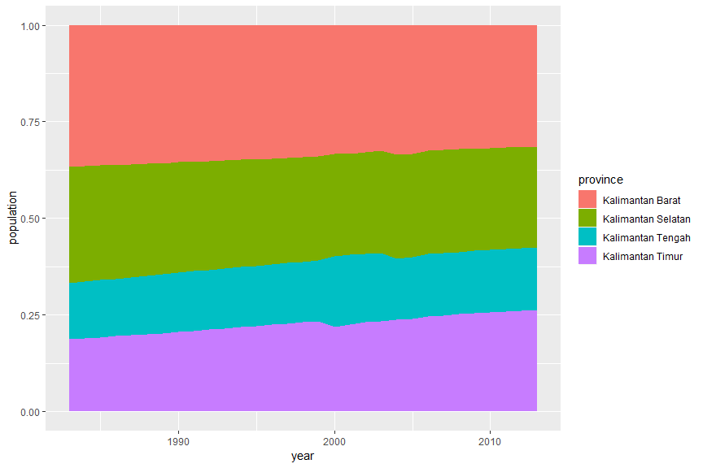

```r
gdp_id %>%
  filter(str_detect(province, "Kalimantan")) %>%
  ggplot(aes(x = year, y = population, fill = province)) +
  geom_area(position = "fill")
```

## Bar Graph

Di bagian selanjutnya, kita akan mempelajari kondisi jalan di Provinsi Jawa Barat pada tahun 2000. Untuk melakukannya, pertama-tama kita harus mempersiapakan data yang didapat dari dataset indodapoer untuk kota/kabupaten di Jawa Barat.

```r
jabar <- c("Bogor, Kab.", "Sukabumi, Kab.", "Cianjur, Kab.", "Bandung, Kab.", "Garut, Kab.", "Tasikmalaya, Kab.", "Ciamis, Kab.", "Kuningan, Kab.", "Cirebon, Kab.", "Majalengka, Kab.", "Sumedang, Kab.", "Indramayu, Kab.", "Subang, Kab.", "Purwakarta, Kab.", "Karawang, Kab.", "Bekasi, Kab.", "Bandung Barat, Kab.", "Pangandaran, Kab.", "Bogor, Kota", "Sukabumi, Kota", "Bandung, Kota", "Cirebon, Kota", "Bekasi, Kota", "Depok, Kota", "Cimahi, Kota", "Tasikmalaya, Kota", "Banjar, Kota")

jabar_road <-
  indodapoer %>%
  filter(province_or_district %in% jabar, year == 2000) %>%
  select(district = province_or_district,
         year,
         ends_with("bina_marga_data")) %>%
  gather("condition", "road_length", length_of_district_road_bad_damage_in_km_bina_marga_data:length_of_district_road_light_damage_in_km_bina_marga_data) %>%
  mutate(
    condition = recode(condition,
                       length_of_district_road_bad_damage_in_km_bina_marga_data = "Bad damage",
                       length_of_district_road_light_damage_in_km_bina_marga_data = "Light damage",
                       length_of_district_road_fair_in_km_bina_marga_data = "Fair",
                       length_of_district_road_good_in_km_bina_marga_data = "Good"),
    condition = factor(condition, levels = c("Bad damage", "Light damage", "Fair", "Good"))
  ) %>%
  drop_na(road_length)
jabar_road
```

```
## # A tibble: 64 x 4
##    district         year condition  road_length
##    <chr>           <dbl> <fct>            <dbl>
##  1 Bandung, Kab.    2000 Bad damage          75
##  2 Bekasi, Kab.     2000 Bad damage         143
##  3 Bogor, Kab.      2000 Bad damage          29
##  4 Ciamis, Kab.     2000 Bad damage         156
##  5 Cianjur, Kab.    2000 Bad damage          45
##  6 Cirebon, Kab.    2000 Bad damage          77
##  7 Garut, Kab.      2000 Bad damage         106
##  8 Indramayu, Kab.  2000 Bad damage         100
##  9 Karawang, Kab.   2000 Bad damage          51
## 10 Kuningan, Kab.   2000 Bad damage          19
## # ... with 54 more rows
```

Kita ingin melihat kota/kabupaten mana saja yang memiliki jalan dengan kondisi baik terpanjang (variabel `road_length`) dengan membuat *bar plot*. Fungsi yang digunakan untuk hal ini adalah `geom_col()`.

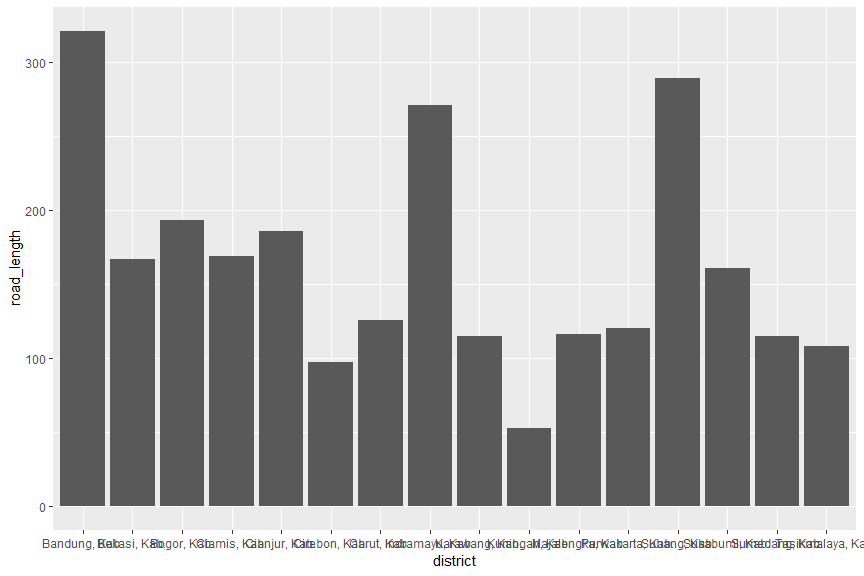

```r
jabar_road %>%
  filter(condition == "Good") %>%
  ggplot(aes(x = district, y = road_length)) +
  geom_col()
```

Kita juga dapat membuat *bar plot* untuk keempat kondisi jalan di tiap kota/kabupaten dengan membuat *grouped bar plot* dan membedakan warna kolom-kolomnya. Untuk menghasilkan *grouped bar plot*, kita menggunakan argumen `position = "dodge"` pada fungsi `geom_col()`. Gunakan variabel `condition` untuk argumen `fill`.

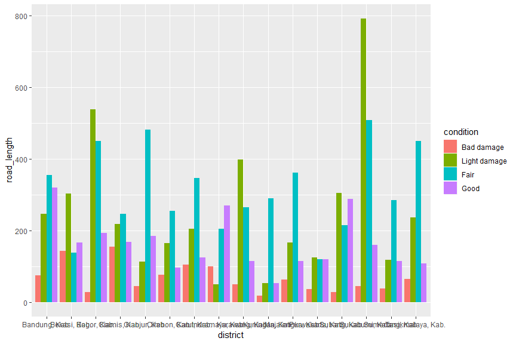

```r
ggplot(jabar_road, aes(x = district, y = road_length, fill = condition)) +
  geom_col(position = "dodge")
```

Kita juga dapat membuat *stacked bar plot* untuk memberikan perhatian pada nilai total panjang jalan keempat kondisi. Kita cukup menghapus argumen `position = dodge` untuk melakukannya.

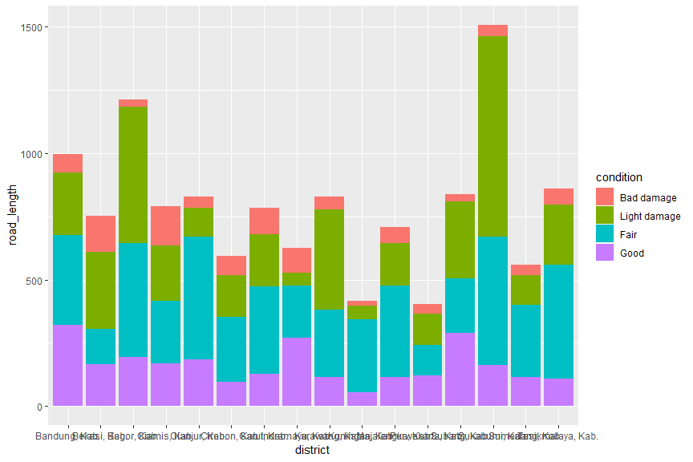

```r
ggplot(jabar_road, aes(x = district, y = road_length, fill = condition)) +
  geom_col()
```

Jika kita lebih tertarik pada kontribusi relatif dari masing-masing kondisi jalan, kita dapat menormalisasi nilai dengan total panjang jalan di tiap kota/kabupaten menggunakan argumen `position = fill`.

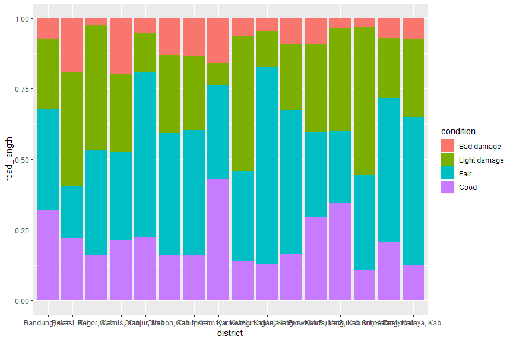

```r
ggplot(jabar_road, aes(x = district, y = road_length, fill = condition)) +
  geom_col(position="fill")
```

Kita juga dapat mengganti label untuk sumbu y sehingga menampilkan persentase. Untuk itu, kita menambahkan fungsi dan argumen `scale_y_continuous(labels = scales::percent)`.

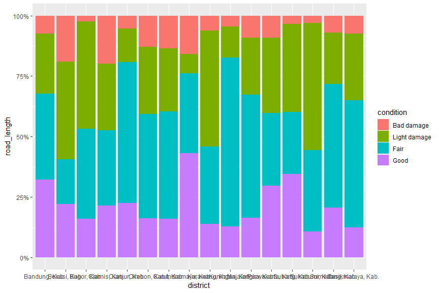

```r
ggplot(jabar_road, aes(x = district, y = road_length, fill = condition)) +
  geom_col(position = "fill") +
  scale_y_continuous(labels = scales::percent)
```

Selanjutnya kita kembali pada data GDP. Kali ini kita ingin melihat GDP tertinggi di masing-masing provinsi beserta tahun ketika GDP tertinggi di provinsi tersebut terjadi.

```r
highest_gdp <-
  gdp_id %>%
  select(province, year, total_gdp_including_oil_and_gas) %>%
  group_by(province) %>%
  drop_na() %>%
  summarise(
    gdp = max(total_gdp_including_oil_and_gas, na.rm = TRUE),
    year = as.character(year[[which.max(total_gdp_including_oil_and_gas)]])
  )
highest_gdp
```

```
## # A tibble: 33 x 3
##    province             gdp year
##    <chr>              <dbl> <chr>
##  1 Bali           32804381  2012
##  2 Banten         99999846  2012
##  3 Bengkulu        9464274. 2012
##  4 DI Yogyakarta  23309218  2012
##  5 DKI Jakarta   449800000  2012
##  6 Gorontalo       3383620. 2012
##  7 Jambi          20373533  2012
##  8 Jawa Barat    364400000  2012
##  9 Jawa Tengah   210800000  2012
## 10 Jawa Timur    393700000  2012
## # ... with 23 more rows
```

Untuk menyajikan data yang telah kita ekstraksi, kita menggunakan grafik *lollipop* yang merupakan variasi dari *bar plot*.

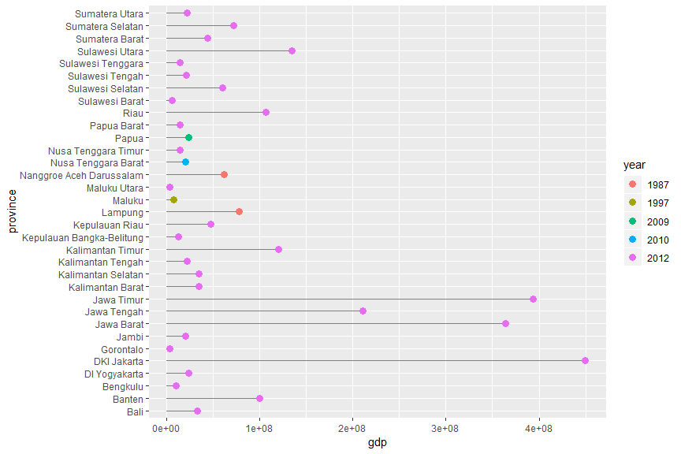

```r
highest_gdp %>%
  ggplot(aes(x = gdp, y = province, colour = year)) +
  geom_segment(aes(yend = province), xend = 0, colour = "grey50") +
  geom_point(size = 3)
```

```r
  geom_label(aes(label = year), size = 2, hjust = -0.2)
```

```
## mapping: label = ~year
## geom_label: parse = FALSE, label.padding = 0.25, label.r = 0.15, label.size = 0.25, na.rm = FALSE
## stat_identity: na.rm = FALSE
## position_identity
```

Agar terlihat lebih rapi dan lebih mudah dipahami, kita dapat mengurutkan nilai GDP mulai tertinggi hingga terendah. Ini dilakukan dengan menambahkan fungsi `fct_reorder()` untuk argumen *aesthetic* pada sumbu y.

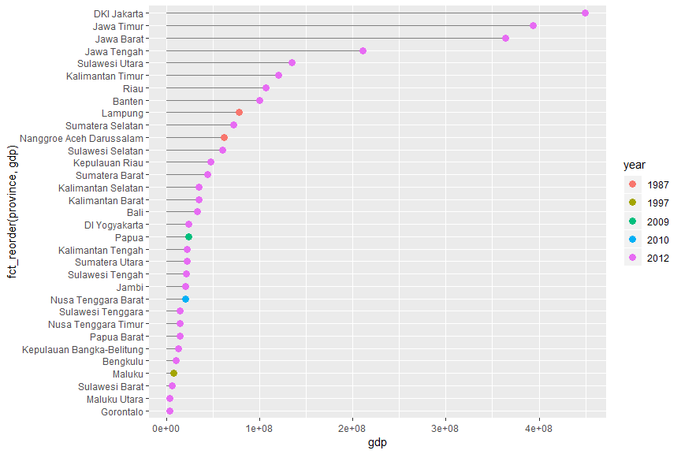

```r
highest_gdp %>%
  ggplot(aes(x = gdp, y = fct_reorder(province, gdp), colour = year)) +
  geom_segment(aes(yend = province), xend = 0, colour = "grey50") +
  geom_point(size = 3)
```

```r
  geom_label(aes(label = year), size = 2, hjust = -0.2)
```

```
## mapping: label = ~year
## geom_label: parse = FALSE, label.padding = 0.25, label.r = 0.15, label.size = 0.25, na.rm = FALSE
## stat_identity: na.rm = FALSE
## position_identity
```

## Choropleth

Selanjutnya kita akan bermain dengan peta menggunakan data geografis. Kita menggunakan data dengan format GeoJSON yaitu states_provinces.json yang berada di direktori data-raw. Untuk membukanya, kita memerlukan paket sf.

```r
library(sf)
geo_id <- st_read("../data-raw/states_provinces.json", stringsAsFactors = FALSE)
geo_id
```

```
## Simple feature collection with 34 features and 59 fields
## geometry type:  MULTIPOLYGON
## dimension:      XY
## bbox:           xmin: 95.01271 ymin: -10.99928 xmax: 140.9776 ymax: 5.910102
## epsg (SRID):    4326
## proj4string:    +proj=longlat +datum=WGS84 +no_defs
## First 10 features:
##    adm1_code OBJECTID_1 diss_me adm1_cod_1 iso_3166_2 wikipedia iso_a2
## 1    IDN+99?       3700   10082    IDN+99?        ID-      <NA>     ID
## 2   IDN-1136        563    1136   IDN-1136        ID-      <NA>     ID
## 3   IDN-1185       1079    1185   IDN-1185        ID-      <NA>     ID
## 4   IDN-1223       1022    1223   IDN-1223        ID-      <NA>     ID
## 5   IDN-1224       1019    1224   IDN-1224        ID-      <NA>     ID
## 6   IDN-1225       1026    1225   IDN-1225        ID-      <NA>     ID
## 7   IDN-1226       1021    1226   IDN-1226        ID-      <NA>     ID
```

[output cut: 124 more lines]

Pertama-tama kita dapat memvisualisasikan peta dari wilayah-wilayah yang terdapat dalam data `geo_id` dengan menggunakan fungsi `geom_sf()`.

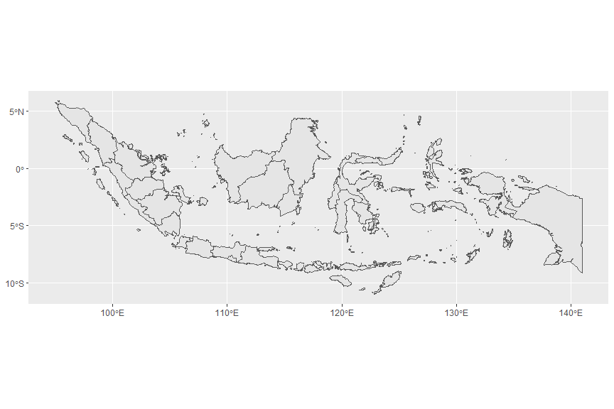

```r
ggplot(geo_id) +
  geom_sf()
```

Sekarang, kita akan mengisi peta di atas dengan data *household access* dari dataset indodapoer. Namun sebelumnya, kita perlu mempersiapkan dan mengekstraksi data yang diperlukan.

```r
household_access <-
  indodapoer %>%
    filter(str_detect(province_or_district, "Prop")) %>%
  select(province = province_or_district,
         year,
         starts_with("household_access")) %>%
  rename_all(~str_remove_all(., "(?:household_access_to_|household_access_to_total_|_in_percent_of_total_household)")) %>%
  mutate(province = str_remove(province, ", Prop.")) %>%
  na.omit() %>%
  arrange(year)
glimpse(household_access)
```

```
## Observations: 144
## Variables: 6
## $ province                    <chr> "Bali", "Bengkulu", "DI Yogyakarta...
## $ year                        <dbl> 1996, 1996, 1996, 1996, 1996, 1996...
## $ electricity_total           <dbl> 89.36, 55.30, 85.57, 99.24, 48.28,...
## $ fixed_line_phone_connection <dbl> 5.284394, 3.857858, 2.023558, 24.3...
## $ safe_sanitation             <dbl> 48.26, 48.09, 57.17, 75.80, 52.83,...
## $ safe_water                  <dbl> 55.83, 21.10, 36.59, 58.35, 25.15,...
```

Kemudian, kita memadukan data `household_access` dengan data `geo_id` menjadi data baru bernama `household_geo`. Untuk kali ini, kita hanya mengambil data di tahun 2011.

```r
household_geo <- full_join(
  filter(household_access, year == 2011),
  geo_id,
  by = c("province" = "name")
)
household_geo
```

```
## # A tibble: 39 x 65
##    province  year electricity_tot~ fixed_line_phon~ safe_sanitation
##    <chr>    <dbl>            <dbl>            <dbl>           <dbl>
##  1 Bali      2011             98.9            15.1             65.5
##  2 Banten    2011             99.3            11.6             62.9
##  3 Bengkulu  2011             87.7             6.18            66.6
##  4 DI Yogy~  2011             99.5             8.93            69.8
##  5 DKI Jak~  2011             99.9            40.0             76.3
##  6 Goronta~  2011             80.9             2.27            33.1
##  7 Jambi     2011             90.5             3.57            68.1
##  8 Jawa Ba~  2011             99.4             9.51            67.6
##  9 Jawa Te~  2011             99.4             4.83            64.5
## 10 Jawa Ti~  2011             99.3             7.10            61.6
## # ... with 29 more rows, and 60 more variables: safe_water <dbl>,
## #   adm1_code <chr>, OBJECTID_1 <int>, diss_me <int>, adm1_cod_1 <chr>,
## #   iso_3166_2 <chr>, wikipedia <chr>, iso_a2 <chr>, adm0_sr <int>,
## #   name_alt <chr>, name_local <chr>, type <chr>, type_en <chr>,
## #   code_local <chr>, code_hasc <chr>, note <chr>, hasc_maybe <chr>,
## #   region <chr>, region_cod <chr>, provnum_ne <int>, gadm_level <int>,
## #   check_me <int>, scalerank <int>, datarank <int>, abbrev <chr>,
## #   postal <chr>, area_sqkm <dbl>, sameascity <int>, labelrank <int>,
## #   featurecla <chr>, name_len <int>, mapcolor9 <int>, mapcolor13 <int>,
## #   fips <chr>, fips_alt <chr>, woe_id <int>, woe_label <chr>,
## #   woe_name <chr>, latitude <dbl>, longitude <dbl>, sov_a3 <chr>,
## #   adm0_a3 <chr>, adm0_label <int>, admin <chr>, geonunit <chr>,
## #   gu_a3 <chr>, gn_id <int>, gn_name <chr>, gns_id <int>, gns_name <chr>,
## #   gn_level <int>, gn_region <chr>, gn_a1_code <chr>, region_sub <chr>,
## #   sub_code <chr>, gns_level <int>, gns_lang <chr>, gns_adm1 <chr>,
## #   gns_region <chr>, geometry <MULTIPOLYGON [Â°]>
```

Setelah memiliki data `household_geo` yang menyimpan informasi geografis dan *household access*, kita dapat memvisualisasikannya dalam bentuk peta. Kita akan mencoba membuat peta tematik (*choropleth*) dari variabel `electricity_total`.

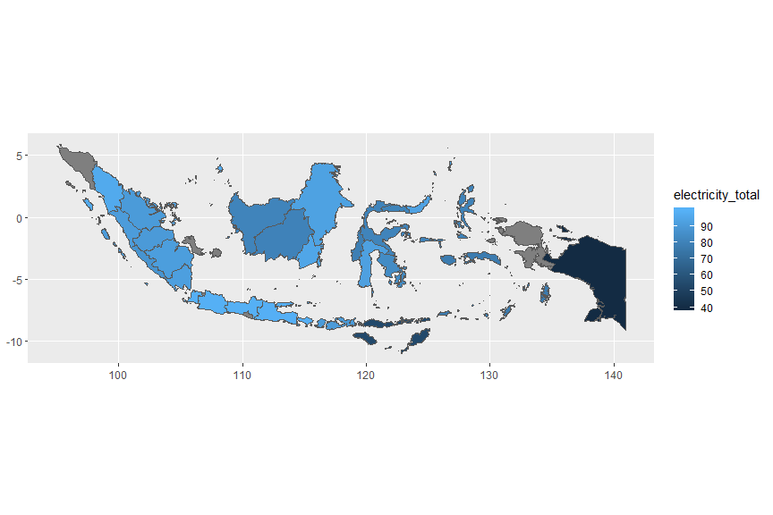

```r
ggplot(household_geo, aes(fill = electricity_total)) +
  geom_sf()
```

Kita dapat mengganti skema warna salah satunya dengan menambahkan fungsi `scale_fill_viridis()` dari paket viridis. Skema warna viridis didesain untuk memudahkan pembacaan, bahkan untuk yang memiliki keterbatasan melihat warna. Selain itu, visualisasi dengan viridis juga akan terlihat baik meskipun dicetak dalam mode *greyscale*.

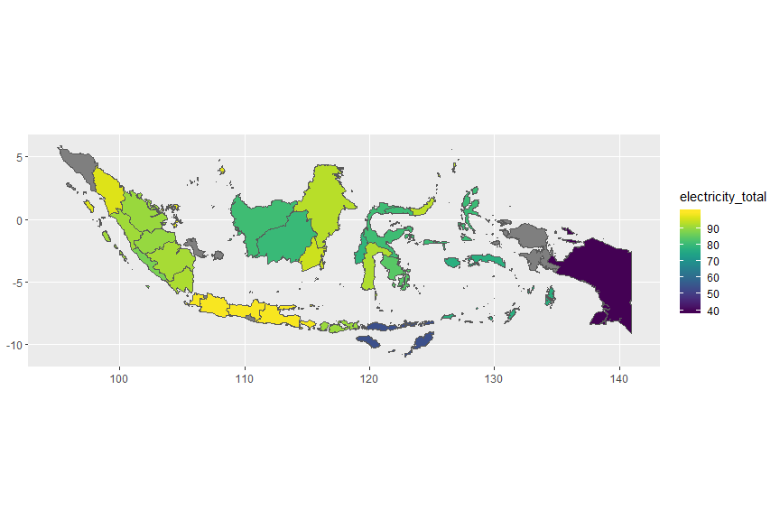

```r
library(viridis)

ggplot(household_geo, aes(fill = electricity_total)) +
  geom_sf() +
  scale_fill_viridis()
```

Sekarang, cobalah untuk mengganti variabel yang ditampilkan menjadi variabel `safe_sanitation`.

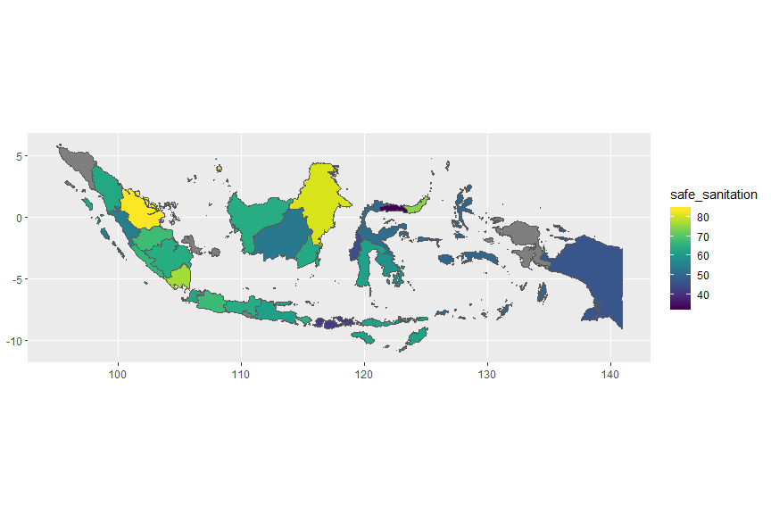

```r
ggplot(household_geo, aes(fill = safe_sanitation)) +
  geom_sf() +
  scale_fill_viridis()
```

## Lain-lain

### Correlation Matrix

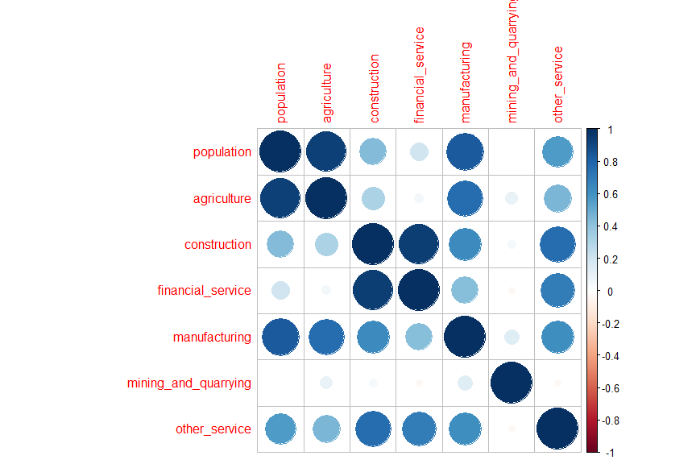

```r
library(corrplot)
gdp_id %>%
  select(population:other_service) %>% cor(use = "pairwise.complete.obs") %>%
  corrplot()
```

### Waffle plot

```r
library(waffle)
savings <- c(
  `Mortgage\n($84,911)` = 84911, `Auto and\ntuition loans\n($14,414)` = 14414,
  `Home equity loans\n($10,062)` = 10062, `Credit Cards\n($8,565)` = 8565
)
waffle(
  savings / 392, rows = 7, size = 0.5, legend_pos = "bottom",
  colors = c("#c7d4b6", "#a3aabd", "#a0d0de", "#97b5cf")
)
```

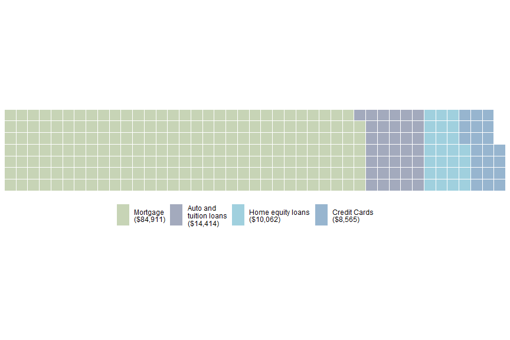

### Heat Map

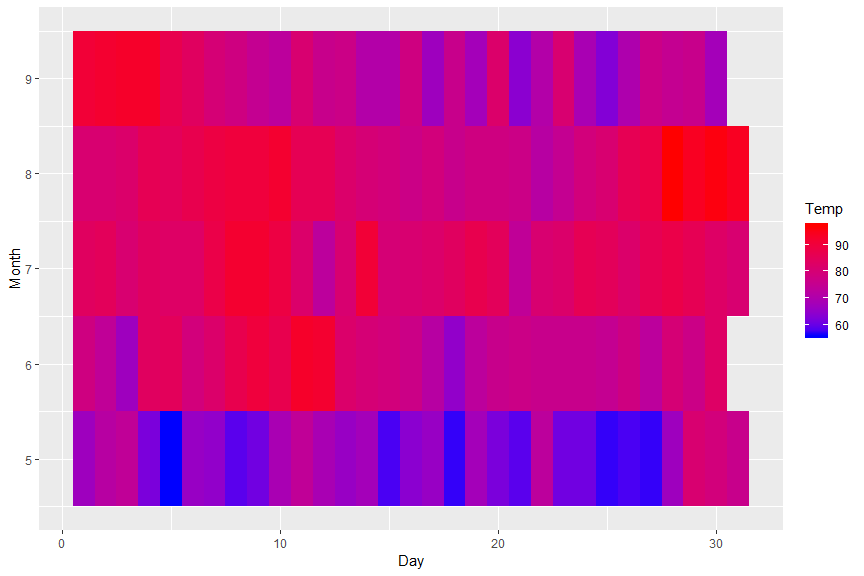

```r
airquality %>%
  ggplot(aes(x = Day, y = Month, fill = Temp)) +
  geom_tile() +
  scale_fill_gradient(low = "blue", high = "red")
```